# chapter 07-1 exercise

kangminji

2021 4 29

**가설설정** H0(귀무가설): 아버지 키가 한단 늘어날 때 아들의 키와 상관이 없다. H1(대립가설): 아버지 키가 한단 늘어날 때 아들의 키와 상관이 있다.

## 아버지와 아들의 키의 회귀식을 구해보고 의미를 파악해보시오.

```r
library(dplyr)
choose.files()
```

```
## [1] "C:\\Workspace\\R\\maestro\\Galtons Height Data.csv"
```

```r
galton <- read.csv("C:\\Workspace\\R\\maestro\\Galtons Height Data.csv")
galton %>% head()
```

```
##   Family Father Mother Gender Height Kids
## 1      1   78.5   67.0      M   73.2    4
## 2      1   78.5   67.0      F   69.2    4
## 3      1   78.5   67.0      F   69.0    4
## 4      1   78.5   67.0      F   69.0    4
## 5      2   75.5   66.5      M   73.5    4
## 6      2   75.5   66.5      M   72.5    4
```

```r
galton %>% dim()
```

```
## [1] 898   6
```

#### 남자만 필터링

```r
galton <- galton %>%
  filter(Gender=="M")
galton %>% head()
```

```
##   Family Father Mother Gender Height Kids
## 1      1   78.5   67.0      M   73.2    4
## 2      2   75.5   66.5      M   73.5    4
## 3      2   75.5   66.5      M   72.5    4
## 4      3   75.0   64.0      M   71.0    2
## 5      4   75.0   64.0      M   70.5    5
## 6      4   75.0   64.0      M   68.5    5
```

#### 아빠와 아들 cm로 변환 하여 기존 데이터에 붙임

```r
galton<- galton %>%
mutate(father=Father*2.54,son=Height*2.54)
```

```r
library(ggplot2)
```

#### 모델 적합 & plot

```r
gal_model <- lm(son~father, data=galton)
coef(gal_model)  #회귀계수
```

```
## (Intercept)      father
##  97.1776370   0.4477479
```

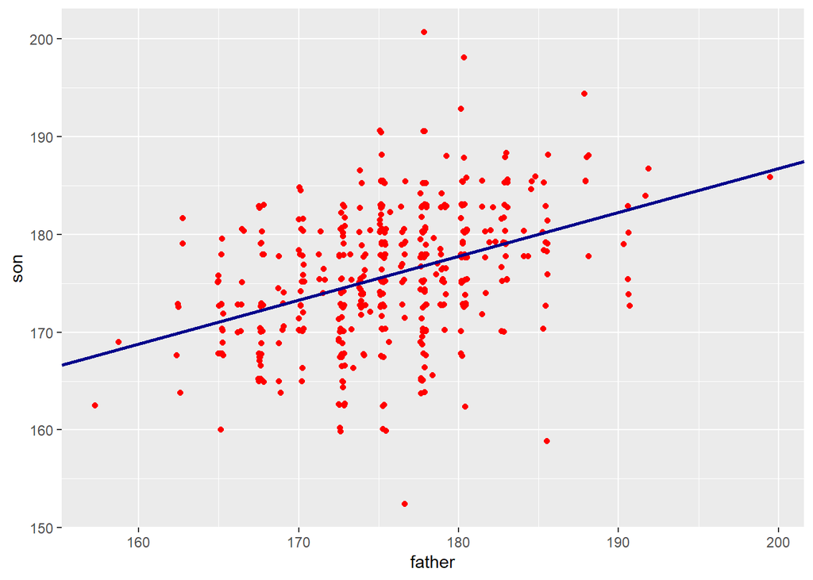

```r
ggplot(galton,aes(father,son))+
  geom_point(position = 'jitter', color='red')+
  geom_abline(intercept = coef(gal_model)[1],slope = coef(gal_model),
              color='darkblue',size=1)
```

```r
summary(gal_model)
```

```
##
## Call:
## lm(formula = son ~ father, data = galton)
##
## Residuals:
##     Min      1Q  Median      3Q     Max
## -23.819  -3.802   0.046   4.159  23.873
##
## Coefficients:
##             Estimate Std. Error t value Pr(>|t|)
## (Intercept) 97.17764    8.60205   11.30   <2e-16 ***
## father       0.44775    0.04894    9.15   <2e-16 ***
## ---
## Signif. codes:  0 '***' 0.001 '**' 0.01 '*' 0.05 '.' 0.1 ' ' 1
##
## Residual standard error: 6.158 on 463 degrees of freedom
## Multiple R-squared:  0.1531, Adjusted R-squared:  0.1513
## F-statistic: 83.72 on 1 and 463 DF,  p-value: < 2.2e-16
```

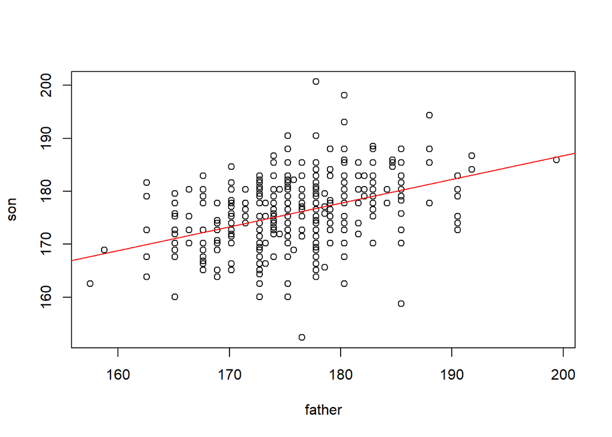

```r
plot(son~father, data=galton)
abline(gal_model, col="red")
```

Adjusted R-squared: 0.1513 => 모델이 적합하지 않다. p-vlaue가 0.05보다 훨씬 작으므로 유의미하다.

```
 [ y= 0.44775 X + 97.17764 ]
```

아들의 키 = 0.44775 * 아버지의 키 + 97.17764 => 아버지의 키가 증가할때마다 아들의 키가 0.44775씩 증가한다. => H1(대립가설)을 채택하고 H0(귀무가설)을 기각한다.

0.44775 * 170 + 97.17764 = 173.2951 0.44775 * 175+ 97.17764 = 175.5339 0.44775 * 180 + 97.17764 = 177.7726 => 아버지의 키를 175 기점으로 175이하면 아들의 키는 아버지보다 크고, 175이상이면 아들의 키는 아버지보다 작다.

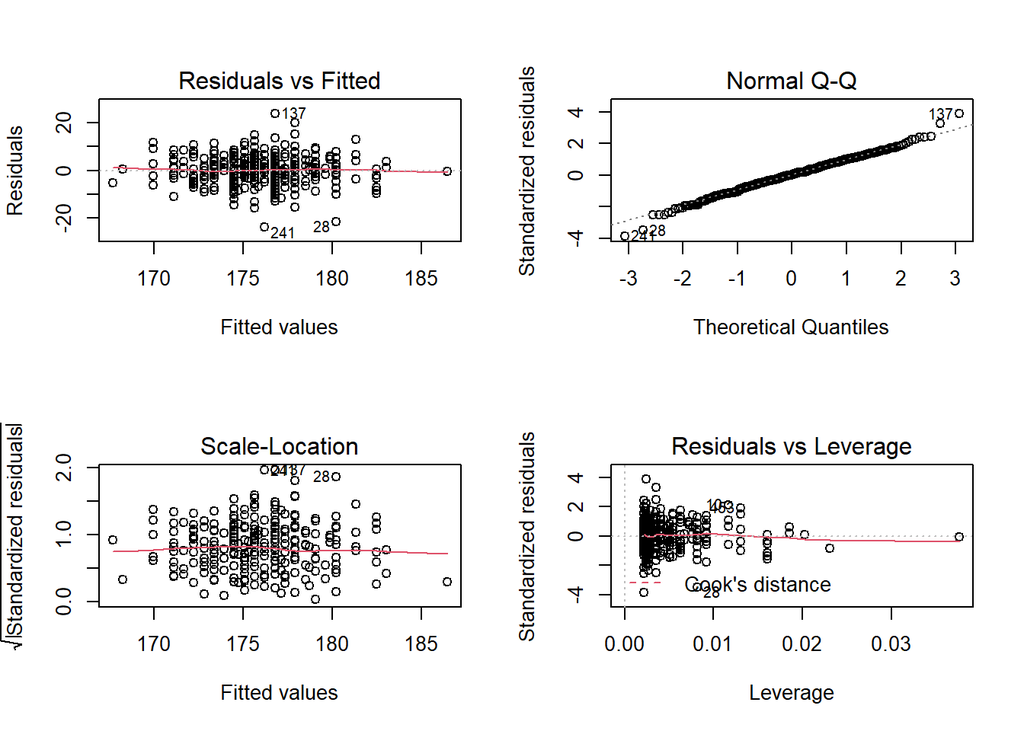

```r
par(mfrow=c(2,2))
plot(gal_model)
```

- Residuals vs Fitted plot가 0을 중심으로 잘 모여있는 편이다. 모형 적합하다. - NormalQ-Q: 선형을 띄고 있음. 선형을 띄지않을때 log10()씌우면 선형모형을 띈다. - Residuals VS Leverage가 한쪽을 치우쳐져있으므로 모형 잘 적합해있다.

#### 다차식 회귀

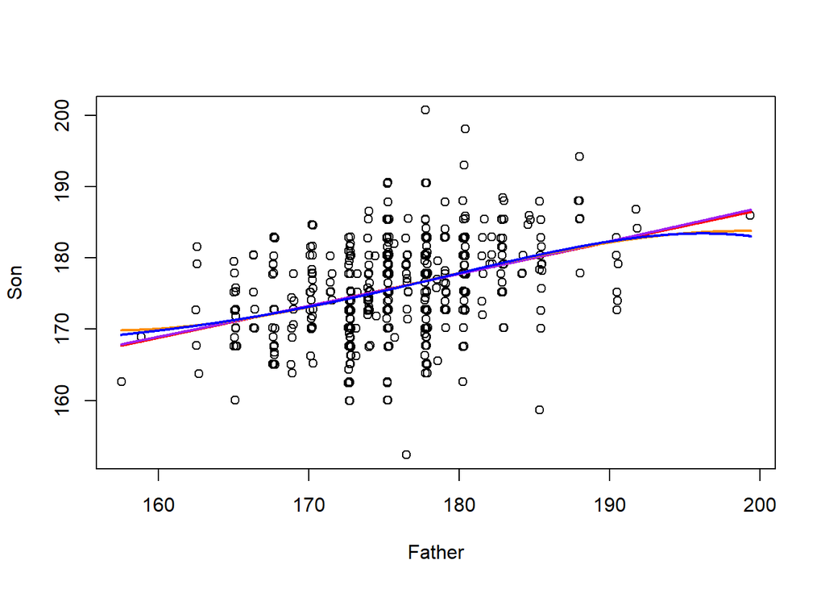

```r
x <- seq(min(galton$father), max(galton$father), length.out=1000)
plot(jitter(galton$father), jitter(galton$son),
     xlab='Father', ylab='Son')
colors <- c('red','purple','darkorange','blue')
for (i in 1:4) {
    m <- lm(son ~ poly(father, i), data=galton)
    assign(paste('m', i, sep='.'), m)
    y <- predict(m, data.frame(father=x))
    lines(x, y, col=colors[i], lwd=2)
}
```

```r
anova(m.1, m.2, m.3, m.4)
```

```
## Analysis of Variance Table
##
## Model 1: son ~ poly(father, i)
## Model 2: son ~ poly(father, i)
## Model 3: son ~ poly(father, i)
## Model 4: son ~ poly(father, i)
##   Res.Df   RSS Df Sum of Sq      F Pr(>F)
## 1    463 17557
## 2    462 17556  1    0.5132 0.0135 0.9077
## 3    461 17531  1   24.7417 0.6493 0.4208
## 4    460 17530  1    1.8148 0.0476 0.8273
```

다차식회귀를 했을때 선형회귀를 했을때와 달리 p-value가 0.05보다 훨씬 커진것을 볼 수 있어 무의미하다. 따라서 위의 회귀식보다 설명력이 떨어진다.